# London Cycle Hires and Weather

## Reformatting

With the data in the current format, not all the questions we want to ask are easy. For example: how does the number of bikes at one station correlate with another at any given time? I previously said it “looks strong”, but that's pretty vague.

To answer questions like that, we need to be somewhat forgiving with our definition of 'any given time'. Updates don't necessarily happen simultaneously, so we need to bin them together.

I'm going to create bins ten minutes wide, and assign every observation to a bin. Then in each bin, we can ask how many bikes were at each station. Using this, we can check correlation between each station:

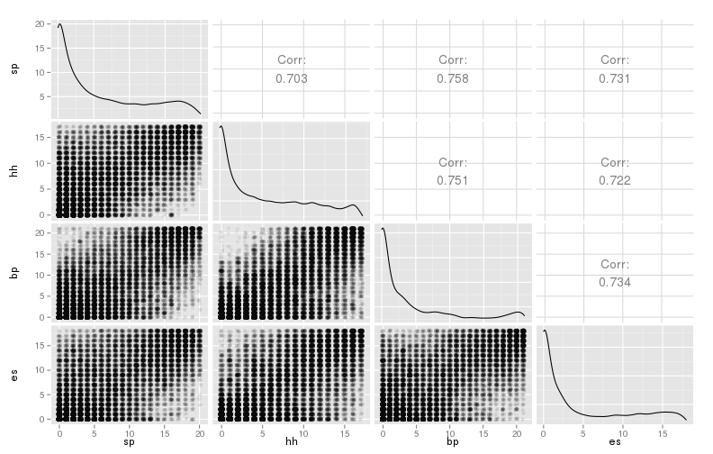

Correlations range between 0.703 and 0.758, and the scatter plots and density histograms all look pretty similar. Does the correlation depend on time? Let's go for 0930, 1800, midnight, and noon.

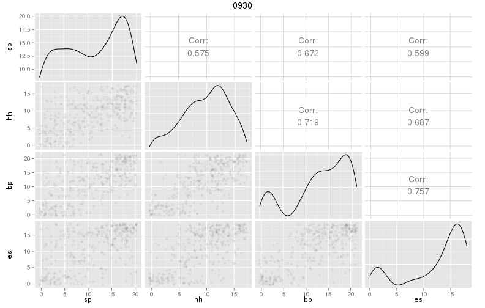

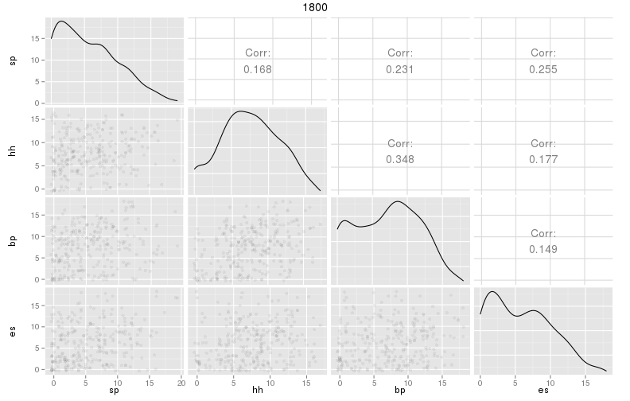

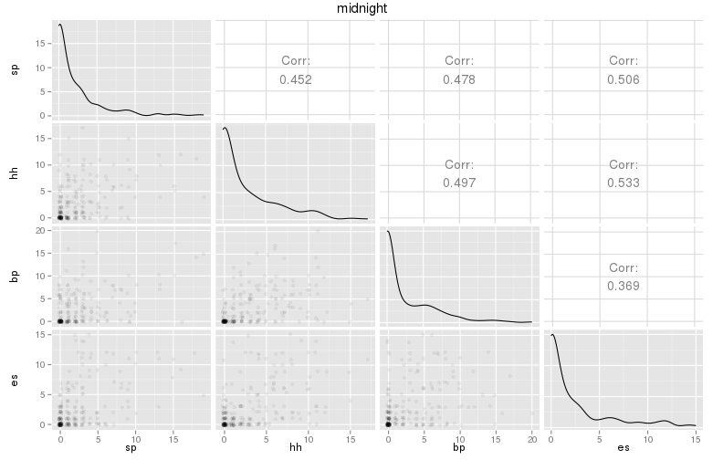

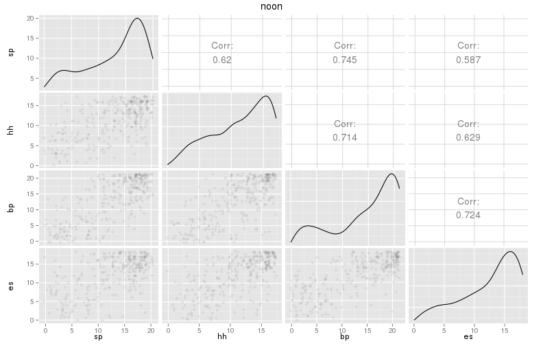

The correlations are almost all lower. That surprised me, but I think it's an example of [Simpson's paradox](http://en.wikipedia.org/wiki/Simpson%27s_paradox). I note that the darkest points in the graph are at midnight, with no bikes in any station much of the time. Bikes are periodically moved in vans to account for anticipated demand; I assume that these stations are emptied most nights to prepare for people coming to work in the morning.

An interesting point is that the weakest correlation on any of the graphs is 0.149, between Earnshaw Street and Bury Place at 1800. But the strongest correlation at a specific time is 0.757, also between those two stations, at 0930.

We also see the density charts sometimes having very different shapes, especially at 0930 and 1800. But this seems to be at least partly to do with the way that `ggpairs` chooses the axes on its density plots. For example, here's 0930:

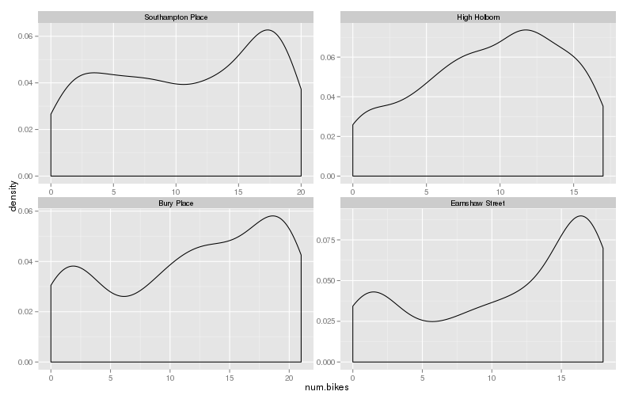

The troughs look a lot less significant now.

We can view a histogram of the total number of bikes available at different times:

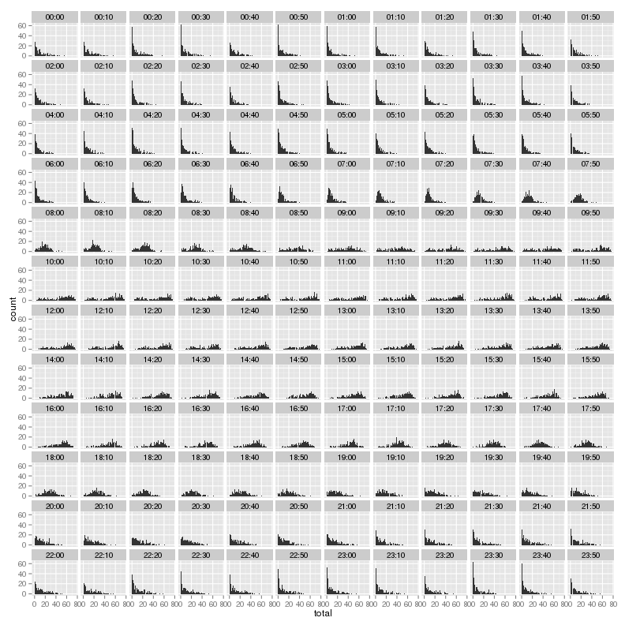

We can also check correlation between times more distant than a single tick. If I check the slots available when I leave the house, can I learn how many will be there when I arrive?

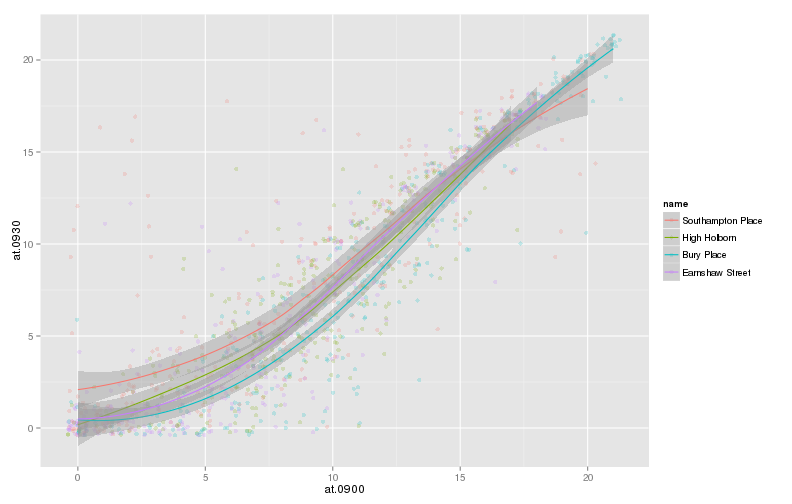

```
##
##  Pearson's product-moment correlation
##
## data:  at.0900 and at.0930
## t = 68.675, df = 1228, p-value < 2.2e-16
## alternative hypothesis: true correlation is not equal to 0
## 95 percent confidence interval:
##  0.8785868 0.9017383
## sample estimates:
##       cor
## 0.8907389
```

This is good correlation! Does it depend on the rain?

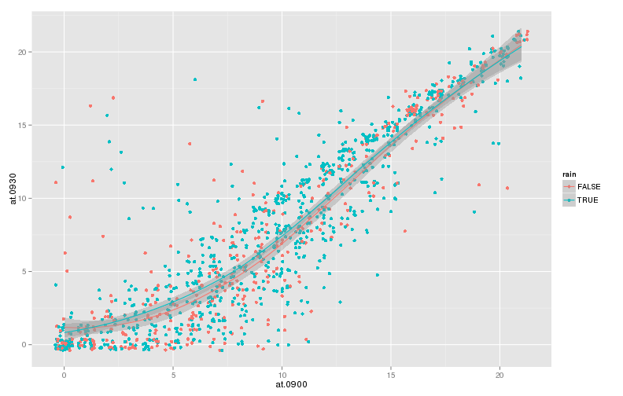

```
##
##  Pearson's product-moment correlation
##
## data:  at.0900[rain] and at.0930[rain]
## t = 55.466, df = 816, p-value < 2.2e-16
## alternative hypothesis: true correlation is not equal to 0
## 95 percent confidence interval:
##  0.8737218 0.9025687
## sample estimates:
##       cor
## 0.8890242
```

```
##
##  Pearson's product-moment correlation
##
## data:  at.0900[!rain] and at.0930[!rain]
## t = 39.748, df = 410, p-value < 2.2e-16
## alternative hypothesis: true correlation is not equal to 0
## 95 percent confidence interval:
##  0.8692649 0.9093735
## sample estimates:
##       cor
## 0.8910456
```

Not much, if at all.

We can construct a model

```
##
## Call:
## lm(formula = at.0930 ~ at.0900, data = spaces.0900.0930)
##
## Residuals:
##    Min     1Q Median     3Q    Max
## -9.334 -1.502  0.561  1.708 16.477
##
## Coefficients:
##             Estimate Std. Error t value Pr(>|t|)
## (Intercept) -1.43496    0.15556  -9.225   <2e-16 ***
## at.0900      0.97899    0.01426  68.675   <2e-16 ***
## ---
## Signif. codes:  0 '***' 0.001 '**' 0.01 '*' 0.05 '.' 0.1 ' ' 1
##
## Residual standard error: 2.802 on 1228 degrees of freedom
##   (69 observations deleted due to missingness)
## Multiple R-squared:  0.7934, Adjusted R-squared:  0.7932
## F-statistic:  4716 on 1 and 1228 DF,  p-value: < 2.2e-16
```

with an R<sup>2</sup> of 0.79, which is okay. But this isn't the best we can do, because it groups all stations together. Ideally we would create one model per station, with inputs from every station.

```
##
## Call:
## lm(formula = at.0930 ~ sp + hh + bp + es, data = spaces.tmp[spaces.tmp$name ==
##     "Southampton Place", ])
##
## Residuals:
##    Min     1Q Median     3Q    Max
## -8.566 -1.857 -0.148  1.152 15.420
##
## Coefficients:
##             Estimate Std. Error t value Pr(>|t|)
## (Intercept) -0.79625    0.47090  -1.691   0.0919 .
## sp           0.74101    0.04179  17.731   <2e-16 ***
## hh           0.05424    0.05307   1.022   0.3075
## bp           0.11811    0.05092   2.320   0.0210 *
## es           0.07909    0.04550   1.738   0.0832 .
## ---
## Signif. codes:  0 '***' 0.001 '**' 0.01 '*' 0.05 '.' 0.1 ' ' 1
##
## Residual standard error: 3.17 on 296 degrees of freedom
##   (17 observations deleted due to missingness)
## Multiple R-squared:  0.736,  Adjusted R-squared:  0.7324
## F-statistic: 206.3 on 4 and 296 DF,  p-value: < 2.2e-16
```

```
##
## Call:
## lm(formula = at.0930 ~ sp + hh + bp + es, data = spaces.tmp[spaces.tmp$name ==
##     "High Holborn", ])
##
## Residuals:
##     Min      1Q  Median      3Q     Max
## -7.4068 -1.1295  0.1503  1.2304  8.3941
##
## Coefficients:
##             Estimate Std. Error t value Pr(>|t|)
## (Intercept) -2.87268    0.29894  -9.610  < 2e-16 ***
## sp           0.08354    0.02653   3.149  0.00181 **
## hh           0.76021    0.03369  22.567  < 2e-16 ***
## bp           0.09533    0.03232   2.949  0.00344 **
## es           0.15937    0.02888   5.518  7.5e-08 ***
## ---
## Signif. codes:  0 '***' 0.001 '**' 0.01 '*' 0.05 '.' 0.1 ' ' 1
##
## Residual standard error: 2.012 on 296 degrees of freedom
##   (17 observations deleted due to missingness)
## Multiple R-squared:  0.8349, Adjusted R-squared:  0.8327
## F-statistic: 374.2 on 4 and 296 DF,  p-value: < 2.2e-16
```

```
##
## Call:
## lm(formula = at.0930 ~ sp + hh + bp + es, data = spaces.tmp[spaces.tmp$name ==
##     "Bury Place", ])
##
## Residuals:
##     Min      1Q  Median      3Q     Max
## -7.3465 -1.3008  0.3121  1.4809  9.4211
##
## Coefficients:
##             Estimate Std. Error t value Pr(>|t|)
## (Intercept) -4.28068    0.32734 -13.077  < 2e-16 ***
## sp           0.18778    0.02907   6.460 4.32e-10 ***
## hh           0.03132    0.03687   0.850 0.396253
## bp           0.91255    0.03538  25.796  < 2e-16 ***
## es           0.11197    0.03160   3.543 0.000459 ***
## ---
## Signif. codes:  0 '***' 0.001 '**' 0.01 '*' 0.05 '.' 0.1 ' ' 1
##
## Residual standard error: 2.201 on 295 degrees of freedom
##   (18 observations deleted due to missingness)
## Multiple R-squared:  0.8969, Adjusted R-squared:  0.8955
## F-statistic: 641.5 on 4 and 295 DF,  p-value: < 2.2e-16
```

```
##
## Call:
## lm(formula = at.0930 ~ sp + hh + bp + es, data = spaces.tmp[spaces.tmp$name ==
##     "Earnshaw Street", ])
##
## Residuals:
##     Min      1Q  Median      3Q     Max
## -7.8978 -1.4508  0.3118  1.3272 11.8323
##
## Coefficients:
##             Estimate Std. Error t value Pr(>|t|)
## (Intercept) -2.98653    0.35005  -8.532 7.60e-16 ***
## sp           0.05579    0.03107   1.796   0.0735 .
## hh           0.03405    0.03945   0.863   0.3887
## bp           0.17361    0.03785   4.587 6.65e-06 ***
## es           0.83329    0.03382  24.638  < 2e-16 ***
## ---
## Signif. codes:  0 '***' 0.001 '**' 0.01 '*' 0.05 '.' 0.1 ' ' 1
##
## Residual standard error: 2.356 on 296 degrees of freedom
##   (17 observations deleted due to missingness)
## Multiple R-squared:  0.8579, Adjusted R-squared:  0.856
## F-statistic: 446.9 on 4 and 296 DF,  p-value: < 2.2e-16
```

Southampton Place has slightly regressed, but the others have improved slightly. In particular, Bury Place gets an R<sup>2</sup> of 0.89, which is pretty good. (It's important to note that this doesn't make our model worse for Southampton Place than the aggregate model. The aggregate model was just overconfident on that station.)

## Final plots and summary

### Plot 1

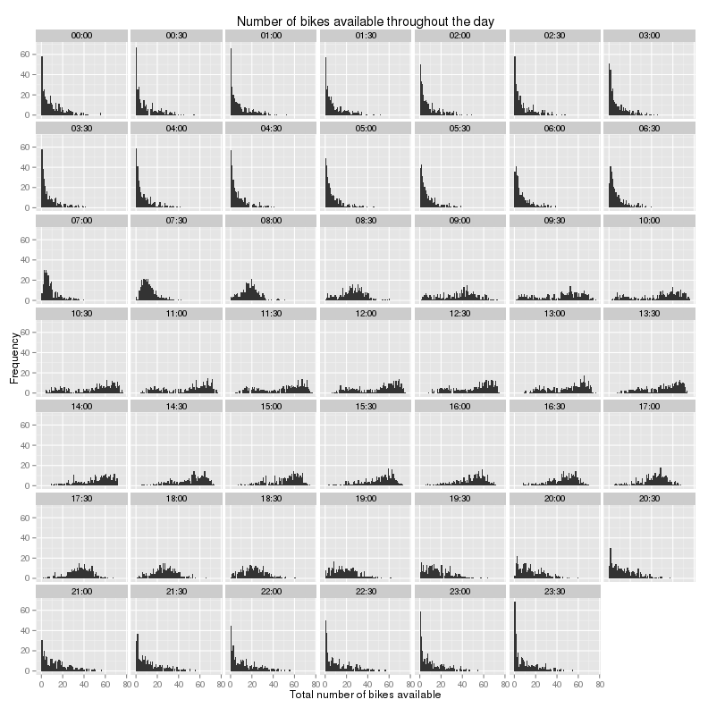

The total number of bikes available changes gradually throughout the day, with few bikes typically available at night, but often many available during the daytime. The distribution looks left-skewed from around 10:00 to 17:00, and right-skewed from around 19:00 to 07:30. The left skew is never as extreme as the right skew, but because the stations have different numbers of slots, that doesn't tell us much.

### Plot 2

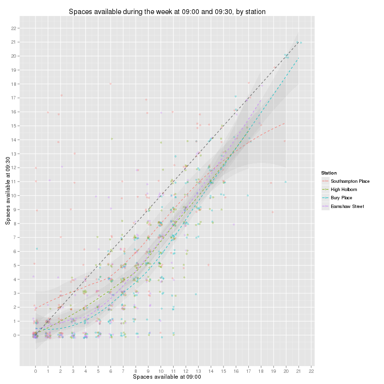

This time around, I restricted the graph to weekdays only. It's rare for the number of stations to go up between 09:00 and 09:30. All four stations have similar usage patterns.

At 09:00, if there are five or fewer spaces available, it looks as though the most common single outcome at 09:30 is no spaces at all.

### Plot 3

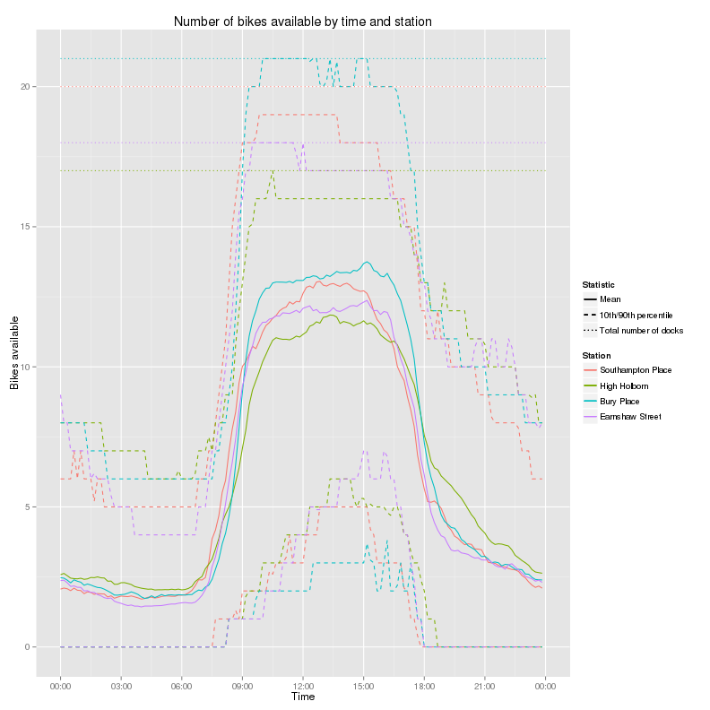

I took advantage of binning to calculate specific summary functions. All stations show similar patterns: at night, there are few bikes available; during office hours, there are almost always some, and the 10-90 percentile range is a lot higher. The trough around 1pm in the previous version of this plot no longer shows up, which makes me suspect it was simply an artifact of the smoothing method.

During the day, the number of bikes available is generally ranked by the number of docking slots at each station - so High Holborn has the least, and Bury Place has the most. When the bikes are taken around 18:00, High Holborn seems to lose them more slowly than the other stations. For Earnshaw Street and especially Bury Place, the 90th percentile lines suggest that those two stations were often completely full.

## Reflection

I've learned a lot about how to fight ggplot when it doesn't do exactly what I want by default, and in particular about how to shape my data for it.

I feel like a data frame isn't an ideal structure for the data I have. The fact that I had to create `prev.*` and `d.*` copies of those columns that need it seems suboptimal, ideally I would have wanted to be able to refer directly to offset rows in the data. (For example, there's currently no easy way to ask “what's the difference between the number of bikes now and 30 minutes ago?”) But I couldn't find anything that worked better. In particular, time series only allow one data type, so I would have had to fight to use them at all, and I don't know if they would have been any more useful.

My data set itself isn't ideal, particularly in the amount of missing data. Unfortunately, I don't think any better historical bike record data is available. I think I have enough data to trust my conclusions.

In general, it seems that weather doesn't have much impact on bike usage. I checked rain, fog, temperature and wind speed, and only rain made a significant difference. But since the rainfall data seems to be internally inconsistent, I don't know how much we can learn from it. It would be useful to validate it from another source. We might also learn more with finer-grained weather data. For example, when predicting bike availability at a specific time, it doesn't help much if we know whether or not it rained at all on a given day; but it might help more to know whether it was raining at that particular time.

On the other hand, we can make pretty good predictions about future bike (and slot) availability just from current availability. An ambitious future project might be a prediction system. A user could specify a station and an arrival time, and the system could tell her how likely it would be that she could find a slot in that station and nearby ones, and suggest an earlier arrival time that would increase that chance.

One thing I didn't examine was [public holidays](http://en.wikipedia.org/wiki/Bank_holiday#List_of_current_holidays_in_the_United_Kingdom.2C_Ireland_and_the_Isle_of_Man). For example, we might ask whether, on plot 2 above, many of the points where spaces were freed up fell on holidays. (We can calculate 85 points above the line, and only 8*4 = 32 of them could be on public holidays, but that's still potentially a third of them.)

After initially submitting this report, I noticed a big problem. All timestamps were collected and reported in physical time, but bike usage patterns are going to be related to clock time. So some of my graphs, particularly later ones, were mixing in data from two different clock times (e.g. 09:00 and 10:00) as if they were the same. I've corrected that error in this version.